# Course Project 2 - Economic and Human Casuality Review of Natural Disasters in the United States

James Sheldon

May 19, 2016

```r
knitr::opts_chunk$set(echo = TRUE)
library(dplyr)
```

## Synopsis

Through analysis of data on natural disasters made available by the (U.S. National Oceanic and Atmospheric Administration $NOAA$)[http://www.noaa.gov] database, an analysis was conducted to understand the economic and life impacts of natural disasters. It was found that tornados have the most overall impact on both the economy and human fatalities by a wide margin. The second widest impacting event on human life is heat and the second widest impacting event on economics is flash flooding.

## Introduction

Storms and other severe weather events can cause both public health and economic problems for communities and municipalities. Many severe events can result in fatalities, injuries, and property damage, and preventing such outcomes to the extent possible is a key concern.

This project involves exploring the U.S. National Oceanic and Atmospheric Administration’s (NOAA) storm database. This database tracks characteristics of major storms and weather events in the United States, including when and where they occur, as well as estimates of any fatalities, injuries, and property damage.

## Data Processing

The data for this assignment come in the form of a comma-separated-value file compressed via the bzip2 algorithm to reduce its size.

```r
dir.create(file.path("./", "data"), showWarnings = FALSE)
setwd(file.path("./"))
download.file("https://d396qusza40orc.cloudfront.net/repdata%2Fdata%2FStormData.csv.bz2", "./data/FStormData.csv.bz2")
stormdata <- read.csv(bzfile("./data/FStormData.csv.bz2"), header = TRUE, sep = ",", na.strings = "NA", stringsAsFactors = FALSE)
download.file("https://raw.githubusercontent.com/mauricio/reproductible-research-assignment-2/master/replacements.csv", "./data/replacements.csv")
replacements <- read.csv("./data/replacements.csv", sep = ",", header = TRUE, stringsAsFactors = FALSE)
download.file("https://raw.githubusercontent.com/mauricio/reproductible-research-assignment-2/master/multipliers.csv", "./data/multipliers.csv")
multipliers <- read.csv("./data/multipliers.csv", sep = ",", header = TRUE, stringsAsFactors = FALSE)
```

Let’s what we have:

```r
head(stormdata)
```

```
##   STATE__           BGN_DATE BGN_TIME TIME_ZONE COUNTY COUNTYNAME STATE
## 1       1  4/18/1950 0:00:00     0130       CST     97     MOBILE    AL
## 2       1  4/18/1950 0:00:00     0145       CST      3    BALDWIN    AL
## 3       1  2/20/1951 0:00:00     1600       CST     57    FAYETTE    AL
## 4       1   6/8/1951 0:00:00     0900       CST     89    MADISON    AL
## 5       1 11/15/1951 0:00:00     1500       CST     43    CULLMAN    AL
## 6       1 11/15/1951 0:00:00     2000       CST     77 LAUDERDALE    AL
##    EVTYPE BGN_RANGE BGN_AZI BGN_LOCATI END_DATE END_TIME COUNTY_END
## 1 TORNADO         0                                               0
## 2 TORNADO         0                                               0
## 3 TORNADO         0                                               0
## 4 TORNADO         0                                               0
## 5 TORNADO         0                                               0
## 6 TORNADO         0                                               0
##   COUNTYENDN END_RANGE END_AZI END_LOCATI LENGTH WIDTH F MAG FATALITIES
```

[output cut: 20 more lines]

```r
str(stormdata)
```

```
## 'data.frame':    902297 obs. of  37 variables:
##  $ STATE__   : num  1 1 1 1 1 1 1 1 1 1 ...
##  $ BGN_DATE  : chr  "4/18/1950 0:00:00" "4/18/1950 0:00:00" "2/20/1951 0:00:00" "6/8/1951 0:00:00" ...
##  $ BGN_TIME  : chr  "0130" "0145" "1600" "0900" ...
##  $ TIME_ZONE : chr  "CST" "CST" "CST" "CST" ...
##  $ COUNTY    : num  97 3 57 89 43 77 9 123 125 57 ...
##  $ COUNTYNAME: chr  "MOBILE" "BALDWIN" "FAYETTE" "MADISON" ...
##  $ STATE     : chr  "AL" "AL" "AL" "AL" ...
##  $ EVTYPE    : chr  "TORNADO" "TORNADO" "TORNADO" "TORNADO" ...
##  $ BGN_RANGE : num  0 0 0 0 0 0 0 0 0 0 ...
##  $ BGN_AZI   : chr  "" "" "" "" ...
##  $ BGN_LOCATI: chr  "" "" "" "" ...
##  $ END_DATE  : chr  "" "" "" "" ...
##  $ END_TIME  : chr  "" "" "" "" ...
##  $ COUNTY_END: num  0 0 0 0 0 0 0 0 0 0 ...
```

[output cut: 23 more lines]

*Yuck*. Let’s tidy this up a bit. In particular, the dates should be formated properly. For purposes of this analysis we needn’t worry about the times.

Let’s turn `BGN_DATE` into a useable date format.

```r
stormdata$BGN_DATE <- as.Date(stormdata$BGN_DATE, "%m/%d/%Y")
```

Now let’s grab just a subset of the data needed for the analysis.

```r
stormsubset <- select(stormdata, EVTYPE, BGN_DATE, FATALITIES, INJURIES, PROPDMG, PROPDMGEXP, CROPDMG, CROPDMGEXP)
```

Next up, based on what we’re being asked to review, we need to get a handle on a few of the parameters. Most namely we need to focus on getting the economic identifiers `PROPDMGEXP` and `CROPDMGEXP` uniform throughout the data. Let’s take a look at each of these to see what they look like.

```r
stormsubset %>% group_by(PROPDMGEXP) %>% summarise_each(funs(sum), FATALITIES, INJURIES, PROPDMG, CROPDMG)
```

```
## Source: local data frame [19 x 5]
##
##    PROPDMGEXP FATALITIES INJURIES     PROPDMG   CROPDMG
##         (chr)      (dbl)    (dbl)       (dbl)     (dbl)
## 1                   5635    20620      527.41 238604.47
## 2           -          2        0       15.00      0.00
## 3           ?          0        0        0.00      0.00
## 4           +          0        0      117.00      0.00
## 5           0          3       33     7108.30    216.50
## 6           1          0        0        0.00      0.00
## 7           2          0        0       12.00      0.00
## 8           3          0        0       20.00      2.50
## 9           4          0        0       14.50      0.00
## 10          5          2        0      210.50    455.00
## 11          6          0        0       65.00      0.00
## 12          7          0        1       82.00      0.00
## 13          8          0        0        0.00      0.00
## 14          B        335     2970      275.85   1593.21
## 15          h          0        0        2.00      0.00
## 16          H          0        2       25.00      0.00
## 17          K       4631    42506 10735292.10 955940.09
## 18          m          0       36       38.90     10.00
## 19          M       4537    74360   140694.45 181005.55
```

We can see from the above summary the different types of values in the `PROPDMGEXP` field.

One observation definitely jumps out. Property damage, fatalities and inuries are quite large for values of “K” and “M” in the `PROPDMGEXP` field.

This needs to be cleaned up a bit to be useful to us for analysis purposes. In particular, this is not a case sensitive field so we need to replace lower cases with upper cases. Let’s take care of that now and rerun the summary.

```r
stormsubset$PROPDMGEXP <- toupper(stormsubset$PROPDMGEXP)
```

Let’s take another look.

```r
stormsubset %>% group_by(PROPDMGEXP) %>% summarise_each(funs(sum), FATALITIES, INJURIES, PROPDMG, CROPDMG)
```

```
## Source: local data frame [17 x 5]
##
##    PROPDMGEXP FATALITIES INJURIES     PROPDMG   CROPDMG
##         (chr)      (dbl)    (dbl)       (dbl)     (dbl)
## 1                   5635    20620      527.41 238604.47
## 2           -          2        0       15.00      0.00
## 3           ?          0        0        0.00      0.00
## 4           +          0        0      117.00      0.00
## 5           0          3       33     7108.30    216.50
## 6           1          0        0        0.00      0.00
## 7           2          0        0       12.00      0.00
## 8           3          0        0       20.00      2.50
## 9           4          0        0       14.50      0.00
## 10          5          2        0      210.50    455.00
## 11          6          0        0       65.00      0.00
## 12          7          0        1       82.00      0.00
## 13          8          0        0        0.00      0.00
## 14          B        335     2970      275.85   1593.21
## 15          H          0        2       27.00      0.00
## 16          K       4631    42506 10735292.10 955940.09
## 17          M       4537    74396   140733.35 181015.55
```

Much better!

Now let’s do the same thing for the `CROPDMGEXP` field.

```r
stormsubset %>% group_by(CROPDMGEXP) %>% summarise_each(funs(sum), FATALITIES, INJURIES, PROPDMG, CROPDMG)
```

```
## Source: local data frame [9 x 5]
##
##   CROPDMGEXP FATALITIES INJURIES    PROPDMG    CROPDMG
##        (chr)      (dbl)    (dbl)      (dbl)      (dbl)
## 1                 11635   110008 6848095.41      11.00
## 2          ?          0        0     481.91       0.00
## 3          0          3       20     282.50     260.00
## 4          2          0        0       0.00       0.00
## 5          B         15      104     510.88      13.61
## 6          k          0        0     338.00     436.00
## 7          K       3072    24008 3887900.47 1342955.91
## 8          m          0        0      20.00      10.00
## 9          M        420     6388  146870.84   34140.80
```

There are case sensitivity issues again. But that’s an easy fix. Let’s take care of it and re-review the summary.

```r
stormsubset$CROPDMGEXP <- toupper(stormsubset$CROPDMGEXP)
stormsubset %>% group_by(CROPDMGEXP) %>% summarise_each(funs(sum), FATALITIES, INJURIES, PROPDMG, CROPDMG)
```

```
## Source: local data frame [7 x 5]
##
##   CROPDMGEXP FATALITIES INJURIES    PROPDMG    CROPDMG
##        (chr)      (dbl)    (dbl)      (dbl)      (dbl)
## 1                 11635   110008 6848095.41      11.00
## 2          ?          0        0     481.91       0.00
## 3          0          3       20     282.50     260.00
## 4          2          0        0       0.00       0.00
## 5          B         15      104     510.88      13.61
## 6          K       3072    24008 3888238.47 1343391.91
## 7          M        420     6388  146890.84   34150.80
```

Much better! As we can see from this summary, events with values of “K” and “M” in the `CROPDMGEXP` field are causing some significant fatalities, injuries, property damage and crop damage. Bottom line, these are miserable. Also worth noting are blank values. These yield significant impacts to fatalities, injuries and property damage but no real issue to crops.

Let’s take a look at the events, match them up and get a sense in actual English what’s going on.

For this part of the data cleanup process I defer to the excellent helping hand provided by [Mauricio](http://mauricio.github.io/2014/12/23/getting-and-clearning-data.html). He walked the extra mile by taking a look at the following summary and cleaned up the event names to be much more cogent and simplified.

```r
stormsubset %>% group_by(EVTYPE) %>% summarise_each(funs(sum), FATALITIES, INJURIES, PROPDMG, CROPDMG)
```

```
## Source: local data frame [985 x 5]
##
##                   EVTYPE FATALITIES INJURIES PROPDMG CROPDMG
##                    (chr)      (dbl)    (dbl)   (dbl)   (dbl)
## 1     HIGH SURF ADVISORY          0        0     200       0
## 2          COASTAL FLOOD          0        0       0       0
## 3            FLASH FLOOD          0        0      50       0
## 4              LIGHTNING          0        0       0       0
## 5              TSTM WIND          0        0     108       0
## 6        TSTM WIND (G45)          0        0       8       0
## 7             WATERSPOUT          0        0       0       0
## 8                   WIND          0        0       0       0
## 9                      ?          0        0       5       0
## 10       ABNORMAL WARMTH          0        0       0       0
## ..                   ...        ...      ...     ...     ...
```

The following code first puts all `EVTYPE` observations to upper case for uniformity. It then takes each observation, cleans up extra spacing and finally, via the `eventFor` function, maps the events to a much simplified and cleaned up set.

```r
stormsubset$EVTYPE <- toupper(gsub("^\\s+|\\s+$", "", stormsubset$EVTYPE))
eventFor <- function( evtype ) {
  replacements[replacements$event == evtype,]$actual
}
stormsubset$EVTYPE <- sapply(stormsubset$EVTYPE, eventFor)

stormsubset %>% group_by(EVTYPE) %>% summarise_each(funs(sum), FATALITIES, INJURIES, PROPDMG, CROPDMG)
```

```
## Source: local data frame [187 x 5]
##
##                        EVTYPE FATALITIES INJURIES  PROPDMG CROPDMG
##                         (chr)      (dbl)    (dbl)    (dbl)   (dbl)
## 1        ACCUMULATED SNOWFALL          0        0     0.00    0.00
## 2         AGRICULTURAL FREEZE          0        0     0.00   28.82
## 3      ASTRONOMICAL HIGH TIDE          0        0   933.50    0.00
## 4       ASTRONOMICAL LOW TIDE          0        0   320.00    0.00
## 5                   AVALANCHE        225      170  1623.90    0.00
## 6               BEACH EROSION          0        0   100.00    0.00
## 7                 BEACH FLOOD          0        0     0.00    0.00
## 8  BELOW NORMAL PRECIPITATION          0        0     0.00    0.00
## 9                   BLACK ICE          1       24     0.00    0.00
## 10                   BLIZZARD        101      805 25818.48  172.00
## ..                        ...        ...      ...      ...     ...
```

Much better! We’ve now taken a summarized set of 985 event types and condensed it to 187!

## Results

Now that we have a uniform naming convention it’s a simple matter to order our events by fatalities, injuries or economic metrics to see the top offenders. Let’s begin with human casualties.

```r
event_summ <- stormsubset %>% group_by(EVTYPE) %>% summarise_each(funs(sum), FATALITIES, INJURIES, PROPDMG, CROPDMG)
head(arrange(event_summ, desc(FATALITIES)))
```

```
## Source: local data frame [6 x 5]
##
##           EVTYPE FATALITIES INJURIES    PROPDMG   CROPDMG
##            (chr)      (dbl)    (dbl)      (dbl)     (dbl)
## 1        TORNADO       5658    91364 3214533.96 100029.22
## 2           HEAT       3134     9176    3232.86   1467.40
## 3    FLASH FLOOD       1035     1800 1474373.90 186484.21
## 4      LIGHTNING        817     5232  603439.78   3580.61
## 5    RIP CURRENT        577      529     163.00      0.00
## 6 TROPICAL STORM        576     7439 1394981.39 120024.37
```

```r
head(arrange(event_summ, desc(INJURIES)))
```

```
## Source: local data frame [6 x 5]
##
##           EVTYPE FATALITIES INJURIES    PROPDMG   CROPDMG
##            (chr)      (dbl)    (dbl)      (dbl)     (dbl)
## 1        TORNADO       5658    91364 3214533.96 100029.22
## 2           HEAT       3134     9176    3232.86   1467.40
## 3 TROPICAL STORM        576     7439 1394981.39 120024.37
## 4          FLOOD        508     6870  952043.72 175650.48
## 5      LIGHTNING        817     5232  603439.78   3580.61
## 6   THUNDERSTORM        201     2452 1329973.25  85781.13
```

Across the full data set we see that *tornados* and *heat*, respectively, result in the most significant number of human catastrophies.

```r
stormsmall <- filter(stormsubset, BGN_DATE >= 1/1/1993)
small_summ <- stormsmall %>% group_by(EVTYPE) %>% summarise_each(funs(sum), FATALITIES, INJURIES, PROPDMG, CROPDMG)
head(arrange(small_summ, desc(FATALITIES)))
```

```
## Source: local data frame [6 x 5]
##
##           EVTYPE FATALITIES INJURIES    PROPDMG   CROPDMG
##            (chr)      (dbl)    (dbl)      (dbl)     (dbl)
## 1        TORNADO       3297    59629 2648375.18 100029.22
## 2           HEAT       3134     9176    3232.86   1467.40
## 3    FLASH FLOOD       1035     1800 1474373.90 186484.21
## 4      LIGHTNING        817     5232  603439.78   3580.61
## 5    RIP CURRENT        577      529     163.00      0.00
## 6 TROPICAL STORM        576     7439 1394981.39 120024.37
```

```r
head(arrange(small_summ, desc(INJURIES)))
```

```
## Source: local data frame [6 x 5]
##
##           EVTYPE FATALITIES INJURIES    PROPDMG   CROPDMG
##            (chr)      (dbl)    (dbl)      (dbl)     (dbl)
## 1        TORNADO       3297    59629 2648375.18 100029.22
## 2           HEAT       3134     9176    3232.86   1467.40
## 3 TROPICAL STORM        576     7439 1394981.39 120024.37
## 4          FLOOD        508     6870  952043.72 175650.48
## 5      LIGHTNING        817     5232  603439.78   3580.61
## 6   THUNDERSTORM        201     2452 1329973.25  85781.13
```

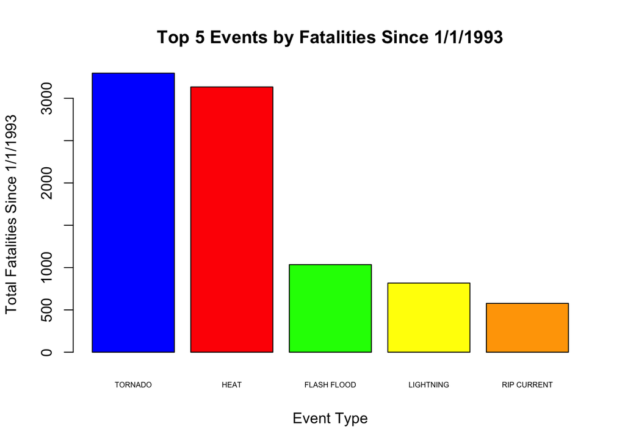

```r
small <- arrange(small_summ, desc(FATALITIES))
barplot(small$FATALITIES[1:5], names.arg = small$EVTYPE[1:5], col = c("blue", "red", "green", "yellow", "orange"), xlab = "Event Type", ylab = "Total Fatalities Since 1/1/1993", main = "Top 5 Events by Fatalities Since 1/1/1993", cex.names = 0.5)
```

What’s interesting about what we’re seeing between this smaller summary and the prior one is the total number of heat incidents remained unchanged. That suggests that heat, as an event, was not being recorded in the early years.

Let’s take a look at these same metrics, but this time focusing on economic metrics. In this instance, there are two differnt economic metrics being observed: crop damage and property damage. We create a new field, “econ”, which is the sum of these two metrics so we have one value to review. It is being scaled by 10^4 for cleanliness sake.

```r
estormsmall <- mutate(stormsmall, econ = ( PROPDMG + CROPDMG) / 10^4)
esmall_summ <- estormsmall %>% group_by(EVTYPE) %>% summarise_each(funs(sum), FATALITIES, INJURIES, econ)
head(arrange(esmall_summ, desc(econ)))
```

```
## Source: local data frame [6 x 4]
##
##           EVTYPE FATALITIES INJURIES     econ
##            (chr)      (dbl)    (dbl)    (dbl)
## 1        TORNADO       3297    59629 274.8404
## 2    FLASH FLOOD       1035     1800 166.0858
## 3 TROPICAL STORM        576     7439 151.5006
## 4   THUNDERSTORM        201     2452 141.5754
## 5           HAIL         15     1371 127.1276
## 6          FLOOD        508     6870 112.7694
```

[figure not shown]

```r
esmall <- arrange(esmall_summ, desc(econ))
barplot(esmall$econ[1:5], names.arg = esmall$EVTYPE[1:5], col = c("blue", "red", "green", "yellow", "orange"), xlab = "Event Type", ylab = "Total Economic Impact Since 1/1/1993 (in billions)", main = "Top 5 Events by Economic Impact Since 1/1/1993", cex.names = 0.5)
```

What we see here is tornados and flash floods account for the largest economic impacting events.